# Data Visualization

## Venustiano Soancatl Aguilar

### Center for Information Technology

### University of Groningen, The Netherlands

### How do visualizations work?

Data is transformed into graphic representations

- Graphics: Marks with visual properties are placed in space
- Encoding: The mapping of data to graphics

### Considerations

- Main goals: gain insights, exploration, explanation, confirmation, presentation, discover hidden patterns
- Audience: conference, paper
- Data type: continuous, discrete
- Data size
- Visualization technique

### Data visualization for exploration

- Data is unknown
- Data may have outliers
- Viewer controls the interaction
- Trying different mappings
- Look for trends and patterns
- Audience are mainly researchers
- Audience is active

### Data visualization for presentation

- Data is well known
- Data has been cleaned
- Audience is mostly passive
- Audience is large

### Kinds of data

[figure not shown]

### Classes of data

[figure not shown]

### Tasks

[figure not shown]

### Examples of tasks

[figure not shown]

### Representation effect, line plot

[figure not shown]

### Representation effect, spyral plot (32 and 28 days cycle)

[figure not shown]

### Visual enconding and representation (visual variables)

[figure not shown]

### Visual variables, a modern version

[figure not shown]

### Key characteristics of visual variables

• Selectivity: “Is A different from B?”

• Associativity: “Is A similar to B?”

• Order: “Is A more/greater/bigger than B?”

• Quantity: “How much is the difference between A and B?”

• Length: “How many different things?”

- Visual variables, original paper http://dx.doi.org/10.11575/PRISM/30495

### Effectiveness ranking of visual variables

[figure not shown]

### Working with some data

Visual Data Exploration for Balance Quantification in Real-Time During Exergaming

https://journals.plos.org/plosone/article?id=10.1371/journal.pone.0170906

If you have a sample dataset that can be used to show examples, feel free to propose it.

```python
# Importing the package
import pandas as pd
```

```python
# Loading and displaying the data
tableRes = pd.read_csv('data/results.txt',sep=' ')
tableRes
```

|  | iSubj | trial | Age | Decade | medLrms51 | medTI51 | medK | meanK | medSpeed | medTIms51 | medLcovD51 | medLsd51 | medLcov51 | medLrmslD51 | medLsdD51 |
| --- | --- | --- | --- | --- | --- | --- | --- | --- | --- | --- | --- | --- | --- | --- | --- |
| 1 | 1 | 1 | 76 | 7 | 0.189493 | 0.589529 | 207.800939 | 333.861515 | 0.488721 | 0.806345 | 0.744766 | 0.020602 | 0.108687 | 1.259172 | 0.129068 |
| 2 | 1 | 2 | 76 | 7 | 0.204152 | 0.697338 | 223.294322 | 319.601546 | 0.518278 | 0.775451 | 0.506944 | 0.016446 | 0.078140 | 1.263366 | 0.105902 |
| 3 | 1 | 3 | 76 | 7 | 0.217347 | 0.786131 | 136.400753 | 272.460861 | 0.584193 | 0.511902 | 0.706127 | 0.047372 | 0.236467 | 0.782796 | 0.133917 |
| 4 | 1 | 4 | 76 | 7 | 0.169569 | 1.020695 | 162.034626 | 289.927862 | 0.590151 | 0.416398 | 0.701803 | 0.039017 | 0.265361 | 0.487570 | 0.108637 |
| 5 | 1 | 5 | 76 | 7 | 0.170786 | 0.769747 | 141.767674 | 300.625818 | 0.551706 | 0.550029 | 0.753161 | 0.036798 | 0.235907 | 0.646194 | 0.119610 |
| ... | ... | ... | ... | ... | ... | ... | ... | ... | ... | ... | ... | ... | ... | ... | ... |
| 396 | 40 | 6 | 58 | 5 | 0.304933 | 0.715350 | 263.249490 | 393.654382 | 0.419596 | 0.989819 | 0.248116 | 0.009786 | 0.031676 | 2.273710 | 0.079016 |
| 397 | 40 | 7 | 58 | 5 | 0.298630 | 0.758093 | 285.346624 | 436.866203 | 0.364656 | 1.154292 | 0.162838 | 0.005467 | 0.017858 | 2.618494 | 0.050360 |
| 398 | 40 | 8 | 58 | 5 | 0.295032 | 0.715015 | 292.177991 | 422.242295 | 0.398149 | 1.077907 | 0.266188 | 0.009360 | 0.031146 | 2.475323 | 0.079460 |
| 399 | 40 | 9 | 58 | 5 | 0.310277 | 0.710607 | 255.888346 | 392.841818 | 0.413573 | 1.023273 | 0.242811 | 0.009074 | 0.028856 | 2.338997 | 0.075648 |
| 400 | 40 | 10 | 58 | 5 | 0.317337 | 0.752008 | 225.649255 | 367.536358 | 0.423233 | 1.002901 | 0.319482 | 0.012942 | 0.042028 | 2.281374 | 0.099211 |

400 rows × 15 columns

## Table operations

- Reshape table
  - wide format
  - long format
- Normalization
- Merge tables
- Filter rows
- Sort rows
- Create an empty table

### Reshaping the data

Wide format

```
   'obs'  'B'  'C'
   a       1    2
   b       3    4
   c       5    6
```

Long format

```
   'obs' 'variables'  'values'
     a        B         1
     b        B         3
     c        B         5
     a        C         2
     b        C         4
     c        C         6
```

### [Wide to long format](https://pandas.pydata.org/docs/reference/api/pandas.melt.html)

```python
df = pd.DataFrame({'A': ['a', 'b', 'c'],
                   'B': [1, 3, 5],
                   'C': [2, 4, 6]})
df
```

|  | A | B | C |
| --- | --- | --- | --- |
| 0 | a | 1 | 2 |
| 1 | b | 3 | 4 |
| 2 | c | 5 | 6 |

```python
pd.melt(df, id_vars=['A'], value_vars=['B', 'C'])
```

|  | A | variable | value |
| --- | --- | --- | --- |
| 0 | a | B | 1 |
| 1 | b | B | 3 |
| 2 | c | B | 5 |
| 3 | a | C | 2 |
| 4 | b | C | 4 |
| 5 | c | C | 6 |

### Converting from wide to long format

```python
l_df = pd.melt(tableRes, id_vars=['iSubj','trial','Age','Decade'],
                    var_name='myVars')
l_df
```

|  | iSubj | trial | Age | Decade | myVars | value |
| --- | --- | --- | --- | --- | --- | --- |
| 0 | 1 | 1 | 76 | 7 | medLrms51 | 0.189493 |
| 1 | 1 | 2 | 76 | 7 | medLrms51 | 0.204152 |
| 2 | 1 | 3 | 76 | 7 | medLrms51 | 0.217347 |
| 3 | 1 | 4 | 76 | 7 | medLrms51 | 0.169569 |
| 4 | 1 | 5 | 76 | 7 | medLrms51 | 0.170786 |
| ... | ... | ... | ... | ... | ... | ... |
| 4395 | 40 | 6 | 58 | 5 | medLsdD51 | 0.079016 |
| 4396 | 40 | 7 | 58 | 5 | medLsdD51 | 0.050360 |
| 4397 | 40 | 8 | 58 | 5 | medLsdD51 | 0.079460 |
| 4398 | 40 | 9 | 58 | 5 | medLsdD51 | 0.075648 |
| 4399 | 40 | 10 | 58 | 5 | medLsdD51 | 0.099211 |

4400 rows × 6 columns

### [From long to wide format](https://pandas.pydata.org/docs/reference/api/pandas.pivot_table.html)

```python
# long format
l_df = pd.melt(df, id_vars=['A'], value_vars=['B', 'C'])
l_df
```

|  | A | variable | value |
| --- | --- | --- | --- |
| 0 | a | B | 1 |
| 1 | b | B | 3 |
| 2 | c | B | 5 |
| 3 | a | C | 2 |
| 4 | b | C | 4 |
| 5 | c | C | 6 |

### Wide format

```python
w_df=l_df.pivot_table(index=['A'],
                      columns='variable', values='value')
w_df
```

| variable A | B | C |
| --- | --- | --- |
| a | 1 | 2 |
| b | 3 | 4 |
| c | 5 | 6 |

```python
w_df.reset_index()
```

| variable | A | B | C |
| --- | --- | --- | --- |
| 0 | a | 1 | 2 |
| 1 | b | 3 | 4 |
| 2 | c | 5 | 6 |

### Our long data

```python
l_df = pd.melt(tableRes, id_vars=['iSubj','trial','Age','Decade'],
                    var_name='myVars')
l_df
```

|  | iSubj | trial | Age | Decade | myVars | value |
| --- | --- | --- | --- | --- | --- | --- |
| 0 | 1 | 1 | 76 | 7 | medLrms51 | 0.189493 |
| 1 | 1 | 2 | 76 | 7 | medLrms51 | 0.204152 |
| 2 | 1 | 3 | 76 | 7 | medLrms51 | 0.217347 |
| 3 | 1 | 4 | 76 | 7 | medLrms51 | 0.169569 |
| 4 | 1 | 5 | 76 | 7 | medLrms51 | 0.170786 |
| ... | ... | ... | ... | ... | ... | ... |
| 4395 | 40 | 6 | 58 | 5 | medLsdD51 | 0.079016 |
| 4396 | 40 | 7 | 58 | 5 | medLsdD51 | 0.050360 |
| 4397 | 40 | 8 | 58 | 5 | medLsdD51 | 0.079460 |
| 4398 | 40 | 9 | 58 | 5 | medLsdD51 | 0.075648 |
| 4399 | 40 | 10 | 58 | 5 | medLsdD51 | 0.099211 |

4400 rows × 6 columns

### From long to wide

```python
w_df=l_df.pivot_table(index=['iSubj','trial','Age','Decade'],
                                columns='myVars', values='value')
w_df
```

| iSubj | trial | Age | myVars Decade | meanK | medK | medLcov51 | medLcovD51 | medLrms51 | medLrmslD51 | medLsd51 | medLsdD51 | medSpeed | medTI51 | medTIms51 |
| --- | --- | --- | --- | --- | --- | --- | --- | --- | --- | --- | --- | --- | --- | --- |
| 1 | 1 | 76 | 7 | 333.861515 | 207.800939 | 0.108687 | 0.744766 | 0.189493 | 1.259172 | 0.020602 | 0.129068 | 0.488721 | 0.589529 | 0.806345 |
|  | 2 | 76 | 7 | 319.601546 | 223.294322 | 0.078140 | 0.506944 | 0.204152 | 1.263366 | 0.016446 | 0.105902 | 0.518278 | 0.697338 | 0.775451 |
|  | 3 | 76 | 7 | 272.460861 | 136.400753 | 0.236467 | 0.706127 | 0.217347 | 0.782796 | 0.047372 | 0.133917 | 0.584193 | 0.786131 | 0.511902 |
|  | 4 | 76 | 7 | 289.927862 | 162.034626 | 0.265361 | 0.701803 | 0.169569 | 0.487570 | 0.039017 | 0.108637 | 0.590151 | 1.020695 | 0.416398 |
|  | 5 | 76 | 7 | 300.625818 | 141.767674 | 0.235907 | 0.753161 | 0.170786 | 0.646194 | 0.036798 | 0.119610 | 0.551706 | 0.769747 | 0.550029 |
| ... | ... | ... | ... | ... | ... | ... | ... | ... | ... | ... | ... | ... | ... | ... |
| 40 | 6 | 58 | 5 | 393.654382 | 263.249490 | 0.031676 | 0.248116 | 0.304933 | 2.273710 | 0.009786 | 0.079016 | 0.419596 | 0.715350 | 0.989819 |
|  | 7 | 58 | 5 | 436.866203 | 285.346624 | 0.017858 | 0.162838 | 0.298630 | 2.618494 | 0.005467 | 0.050360 | 0.364656 | 0.758093 | 1.154292 |
|  | 8 | 58 | 5 | 422.242295 | 292.177991 | 0.031146 | 0.266188 | 0.295032 | 2.475323 | 0.009360 | 0.079460 | 0.398149 | 0.715015 | 1.077907 |
|  | 9 | 58 | 5 | 392.841818 | 255.888346 | 0.028856 | 0.242811 | 0.310277 | 2.338997 | 0.009074 | 0.075648 | 0.413573 | 0.710607 | 1.023273 |
|  | 10 | 58 | 5 | 367.536358 | 225.649255 | 0.042028 | 0.319482 | 0.317337 | 2.281374 | 0.012942 | 0.099211 | 0.423233 | 0.752008 | 1.002901 |

400 rows × 11 columns

### Reset the index

```python
w_df.reset_index()
```

| myVars | iSubj | trial | Age | Decade | meanK | medK | medLcov51 | medLcovD51 | medLrms51 | medLrmslD51 | medLsd51 | medLsdD51 | medSpeed | medTI51 | medTIms51 |
| --- | --- | --- | --- | --- | --- | --- | --- | --- | --- | --- | --- | --- | --- | --- | --- |
| 0 | 1 | 1 | 76 | 7 | 333.861515 | 207.800939 | 0.108687 | 0.744766 | 0.189493 | 1.259172 | 0.020602 | 0.129068 | 0.488721 | 0.589529 | 0.806345 |
| 1 | 1 | 2 | 76 | 7 | 319.601546 | 223.294322 | 0.078140 | 0.506944 | 0.204152 | 1.263366 | 0.016446 | 0.105902 | 0.518278 | 0.697338 | 0.775451 |
| 2 | 1 | 3 | 76 | 7 | 272.460861 | 136.400753 | 0.236467 | 0.706127 | 0.217347 | 0.782796 | 0.047372 | 0.133917 | 0.584193 | 0.786131 | 0.511902 |
| 3 | 1 | 4 | 76 | 7 | 289.927862 | 162.034626 | 0.265361 | 0.701803 | 0.169569 | 0.487570 | 0.039017 | 0.108637 | 0.590151 | 1.020695 | 0.416398 |
| 4 | 1 | 5 | 76 | 7 | 300.625818 | 141.767674 | 0.235907 | 0.753161 | 0.170786 | 0.646194 | 0.036798 | 0.119610 | 0.551706 | 0.769747 | 0.550029 |
| ... | ... | ... | ... | ... | ... | ... | ... | ... | ... | ... | ... | ... | ... | ... | ... |
| 395 | 40 | 6 | 58 | 5 | 393.654382 | 263.249490 | 0.031676 | 0.248116 | 0.304933 | 2.273710 | 0.009786 | 0.079016 | 0.419596 | 0.715350 | 0.989819 |
| 396 | 40 | 7 | 58 | 5 | 436.866203 | 285.346624 | 0.017858 | 0.162838 | 0.298630 | 2.618494 | 0.005467 | 0.050360 | 0.364656 | 0.758093 | 1.154292 |
| 397 | 40 | 8 | 58 | 5 | 422.242295 | 292.177991 | 0.031146 | 0.266188 | 0.295032 | 2.475323 | 0.009360 | 0.079460 | 0.398149 | 0.715015 | 1.077907 |
| 398 | 40 | 9 | 58 | 5 | 392.841818 | 255.888346 | 0.028856 | 0.242811 | 0.310277 | 2.338997 | 0.009074 | 0.075648 | 0.413573 | 0.710607 | 1.023273 |
| 399 | 40 | 10 | 58 | 5 | 367.536358 | 225.649255 | 0.042028 | 0.319482 | 0.317337 | 2.281374 | 0.012942 | 0.099211 | 0.423233 | 0.752008 | 1.002901 |

400 rows × 15 columns

## Normalization)

A couple of methods:

[Standard score](https://en.wikipedia.org/wiki/Standard_score) $$ x' = \frac{x - \mu}{\sigma} $$ [Min-Max Feature scaling](https://en.wikipedia.org/wiki/Feature_scaling) $$ x' = \frac{x - min(x)}{max(x)-min(x)} $$

### Normalizing the long table

```python
l_df["normVal"]=l_df.groupby('myVars').transform(
    lambda value: (value - value.mean()) / value.std())["value"]
l_df
```

|  | iSubj | trial | Age | Decade | myVars | value | normVal |
| --- | --- | --- | --- | --- | --- | --- | --- |
| 0 | 1 | 1 | 76 | 7 | medLrms51 | 0.189493 | -0.406276 |
| 1 | 1 | 2 | 76 | 7 | medLrms51 | 0.204152 | -0.168225 |
| 2 | 1 | 3 | 76 | 7 | medLrms51 | 0.217347 | 0.046049 |
| 3 | 1 | 4 | 76 | 7 | medLrms51 | 0.169569 | -0.729817 |
| 4 | 1 | 5 | 76 | 7 | medLrms51 | 0.170786 | -0.710069 |
| ... | ... | ... | ... | ... | ... | ... | ... |
| 4395 | 40 | 6 | 58 | 5 | medLsdD51 | 0.079016 | -1.090094 |
| 4396 | 40 | 7 | 58 | 5 | medLsdD51 | 0.050360 | -2.066097 |
| 4397 | 40 | 8 | 58 | 5 | medLsdD51 | 0.079460 | -1.074982 |
| 4398 | 40 | 9 | 58 | 5 | medLsdD51 | 0.075648 | -1.204796 |
| 4399 | 40 | 10 | 58 | 5 | medLsdD51 | 0.099211 | -0.402274 |

4400 rows × 7 columns

### Normalizing the wide table

```python
w_df.reset_index(inplace=True)

#Select columns to normalize
cols_to_norm = w_df.columns[4:17]
cols_to_norm

w_df[cols_to_norm] = w_df[cols_to_norm].transform(lambda value: (value - value.mean()) / value.std())
w_df
```

| myVars | iSubj | trial | Age | Decade | meanK | medK | medLcov51 | medLcovD51 | medLrms51 | medLrmslD51 | medLsd51 | medLsdD51 | medSpeed | medTI51 | medTIms51 |
| --- | --- | --- | --- | --- | --- | --- | --- | --- | --- | --- | --- | --- | --- | --- | --- |
| 0 | 1 | 1 | 76 | 7 | 0.024586 | -0.053610 | -0.178508 | 0.332978 | -0.406276 | 0.045147 | -0.194534 | 0.614619 | -0.206204 | -1.179195 | 0.095150 |
| 1 | 1 | 2 | 76 | 7 | -0.226344 | 0.228271 | -0.544866 | -0.389216 | -0.168225 | 0.054335 | -0.465559 | -0.174366 | 0.155747 | -0.344193 | -0.062731 |
| 2 | 1 | 3 | 76 | 7 | -1.055870 | -1.352643 | 1.353981 | 0.215643 | 0.046049 | -0.998491 | 1.551026 | 0.779784 | 0.962942 | 0.343531 | -1.409570 |
| 3 | 1 | 4 | 76 | 7 | -0.748506 | -0.886268 | 1.700509 | 0.202514 | -0.729817 | -1.645271 | 1.006211 | -0.081213 | 1.035904 | 2.160290 | -1.897633 |
| 4 | 1 | 5 | 76 | 7 | -0.560256 | -1.254999 | 1.347267 | 0.358471 | -0.710069 | -1.297759 | 0.861507 | 0.292489 | 0.565108 | 0.216632 | -1.214724 |
| ... | ... | ... | ... | ... | ... | ... | ... | ... | ... | ... | ... | ... | ... | ... | ... |
| 395 | 40 | 6 | 58 | 5 | 1.076750 | 0.955203 | -1.102122 | -1.175201 | 1.468353 | 2.267786 | -0.899767 | -1.090094 | -1.052715 | -0.204683 | 1.032779 |
| 396 | 40 | 7 | 58 | 5 | 1.837141 | 1.357231 | -1.267848 | -1.434162 | 1.365997 | 3.023135 | -1.181429 | -2.066097 | -1.725497 | 0.126370 | 1.873299 |
| 397 | 40 | 8 | 58 | 5 | 1.579807 | 1.481519 | -1.108473 | -1.120321 | 1.307570 | 2.709477 | -0.927597 | -1.074982 | -1.315347 | -0.207280 | 1.482941 |
| 398 | 40 | 9 | 58 | 5 | 1.062452 | 0.821277 | -1.135941 | -1.191309 | 1.555134 | 2.410816 | -0.946214 | -1.204796 | -1.126462 | -0.241420 | 1.203738 |
| 399 | 40 | 10 | 58 | 5 | 0.617156 | 0.271116 | -0.977967 | -0.958482 | 1.669779 | 2.284577 | -0.693999 | -0.402274 | -1.008167 | 0.079243 | 1.099630 |

400 rows × 15 columns

#### Exercise: apply min max normalization to the wide and long dataframes (5 min)

```python
l_df
w_df
```

| myVars | iSubj | trial | Age | Decade | meanK | medK | medLcov51 | medLcovD51 | medLrms51 | medLrmslD51 | medLsd51 | medLsdD51 | medSpeed | medTI51 | medTIms51 |
| --- | --- | --- | --- | --- | --- | --- | --- | --- | --- | --- | --- | --- | --- | --- | --- |
| 0 | 1 | 1 | 76 | 7 | 0.024586 | -0.053610 | -0.178508 | 0.332978 | -0.406276 | 0.045147 | -0.194534 | 0.614619 | -0.206204 | -1.179195 | 0.095150 |
| 1 | 1 | 2 | 76 | 7 | -0.226344 | 0.228271 | -0.544866 | -0.389216 | -0.168225 | 0.054335 | -0.465559 | -0.174366 | 0.155747 | -0.344193 | -0.062731 |
| 2 | 1 | 3 | 76 | 7 | -1.055870 | -1.352643 | 1.353981 | 0.215643 | 0.046049 | -0.998491 | 1.551026 | 0.779784 | 0.962942 | 0.343531 | -1.409570 |
| 3 | 1 | 4 | 76 | 7 | -0.748506 | -0.886268 | 1.700509 | 0.202514 | -0.729817 | -1.645271 | 1.006211 | -0.081213 | 1.035904 | 2.160290 | -1.897633 |
| 4 | 1 | 5 | 76 | 7 | -0.560256 | -1.254999 | 1.347267 | 0.358471 | -0.710069 | -1.297759 | 0.861507 | 0.292489 | 0.565108 | 0.216632 | -1.214724 |
| ... | ... | ... | ... | ... | ... | ... | ... | ... | ... | ... | ... | ... | ... | ... | ... |
| 395 | 40 | 6 | 58 | 5 | 1.076750 | 0.955203 | -1.102122 | -1.175201 | 1.468353 | 2.267786 | -0.899767 | -1.090094 | -1.052715 | -0.204683 | 1.032779 |
| 396 | 40 | 7 | 58 | 5 | 1.837141 | 1.357231 | -1.267848 | -1.434162 | 1.365997 | 3.023135 | -1.181429 | -2.066097 | -1.725497 | 0.126370 | 1.873299 |
| 397 | 40 | 8 | 58 | 5 | 1.579807 | 1.481519 | -1.108473 | -1.120321 | 1.307570 | 2.709477 | -0.927597 | -1.074982 | -1.315347 | -0.207280 | 1.482941 |
| 398 | 40 | 9 | 58 | 5 | 1.062452 | 0.821277 | -1.135941 | -1.191309 | 1.555134 | 2.410816 | -0.946214 | -1.204796 | -1.126462 | -0.241420 | 1.203738 |
| 399 | 40 | 10 | 58 | 5 | 0.617156 | 0.271116 | -0.977967 | -0.958482 | 1.669779 | 2.284577 | -0.693999 | -0.402274 | -1.008167 | 0.079243 | 1.099630 |

400 rows × 15 columns

### Histogram (1D)

Let's create a histogram using the `medSpeed` column

```python
tableRes["medSpeed"]
```

```
1      0.488721
2      0.518278
3      0.584193
4      0.590151
5      0.551706
         ...
396    0.419596
397    0.364656
398    0.398149
399    0.413573
400    0.423233
Name: medSpeed, Length: 400, dtype: float64
```

### Python packages

Plotly + Cufflinks

https://plotly.com/python/getting-started/

The plotly Python library (plotly.py) is an interactive, open-source plotting library.

https://github.com/santosjorge/cufflinks

This library binds the power of plotly with the flexibility of pandas for easy plotting.

### If `cufflinks` is missing

```
import cufflinks as cf
--------------------------------------------------------------------------
ModuleNotFoundError                       Traceback (most recent call last)
<ipython-input-6-3178e833bc72> in <module>
----> 1 import cufflinks as cf
ModuleNotFoundError: No module named 'cufflinks'
```

Temporal solution, remove the `#` in the following cell and run the cell

```python
#!conda install -y -c conda-forge cufflinks-py
```

### Persistent solution

Create Dockerfile.datavis01

```
FROM jupyter/datascience-notebook:8b4d6f6ac0d7

RUN conda install -y -c conda-forge cufflinks-py
```

Building the image

```
$ docker build -t jupyter/datascience-notebook:vis \
        -f docker/Dockerfile.datavis01 docker/
```

Running the container

```
$ docker run --rm -p 8888:8888 -e JUPYTER_ENABLE_LAB=yes \
    -v "$PWD":/home/jovyan/work jupyter/datascience-notebook:vis
```

```python
# https://github.com/plotly/plotly.py/issues/1664#issuecomment-511773518
import plotly.graph_objects as go
import plotly.io as pio

# Set default renderer
pio.renderers.default = 'notebook+jupyterlab'  #  See [1]
# Set default template
pio.templates['slides'] = go.layout.Template(layout=dict(width=800, height=600))
pio.templates.default = 'plotly+slides'  # See [2]
```

```python
# Importing the packages
from plotly.offline import iplot
import cufflinks as cf
cf.go_offline()

# some help
cf.help()
```

```
Use 'cufflinks.help(figure)' to see the list of available parameters for the given figure.
Use 'DataFrame.iplot(kind=figure)' to plot the respective figure
Figures:
	bar
	box
	bubble
	bubble3d
	candle
	choroplet
	distplot
	heatmap
	histogram
	ohlc
	pie
	ratio
	scatter
	scatter3d
	scattergeo
	spread
	surface
	violin
```

```python
# First plot
tableRes['medSpeed'].iplot(kind='hist', bins=50, xTitle='Speed',
    linecolor='black', yTitle='count', title='Speed Distribution')
```

[interactive chart not shown]

```python
# Sometimes, things do not work
# Try to add a curve distribution (fails, scroll down to read the error)
pd.DataFrame(tableRes['medSpeed']).iplot(
    kind='distplot',
    bin_size=0.1,)
```

```
---------------------------------------------------------------------------
AttributeError                            Traceback (most recent call last)
<ipython-input-20-a5a7f1e9bcfc> in <module>
      1 # Sometimes, things do not work
      2 # Try to add a curve distribution (fails, scroll down to read the error)
----> 3 pd.DataFrame(tableRes['medSpeed']).iplot(
      4     kind='distplot',
      5     bin_size=0.1,)

/opt/conda/lib/python3.8/site-packages/cufflinks/plotlytools.py in _iplot(self, kind, data, layout, filename, sharing, title, xTitle, yTitle, zTitle, theme, colors, colorscale, fill, width, dash, mode, interpolation, symbol, size, barmode, sortbars, bargap, bargroupgap, bins, histnorm, histfunc, ori…
   1214                 return Figure(figure)
   1215         else:
-> 1216 		return iplot(figure,validate=validate,sharing=sharing,filename=filename,
   1217                          online=online,asImage=asImage,asUrl=asUrl,asPlot=asPlot,
   1218 			 dimensions=dimensions,display_image=kwargs.get('display_image',True))

/opt/conda/lib/python3.8/site-packages/cufflinks/plotlytools.py in iplot(figure, validate, sharing, filename, online, asImage, asUrl, asPlot, dimensions, display_image, **kwargs)
   1466         ## iplot
   1467         if offline.is_offline() and not online:
-> 1468                 return offline.py_offline.iplot(figure, validate=validate, filename=filename, show_link=show_link, link_text=link_text, config=config)
   1469         else:
   1470 		return py.iplot(figure,validate=validate,sharing=sharing,

/opt/conda/lib/python3.8/site-packages/plotly/offline/offline.py in iplot(figure_or_data, show_link, link_text, validate, image, filename, image_width, image_height, config, auto_play, animation_opts)
    390
    391     # Show figure
--> 392     pio.show(
    393         figure,
    394         validate=validate,

/opt/conda/lib/python3.8/site-packages/plotly/io/_renderers.py in show(fig, renderer, validate, **kwargs)
    387
    388     # Mimetype renderers
--> 389     bundle = renderers._build_mime_bundle(fig_dict, renderers_string=renderer, **kwargs)
    390     if bundle:
    391         if not ipython_display:

/opt/conda/lib/python3.8/site-packages/plotly/io/_renderers.py in _build_mime_bundle(self, fig_dict, renderers_string, **kwargs)
    295                         setattr(renderer, k, v)
    296
```

[output cut: 11 more lines]

```
/opt/conda/lib/python3.8/site-packages/plotly/io/_html.py in to_html(fig, config, auto_play, include_plotlyjs, include_mathjax, post_script, full_html, animation_opts, default_width, default_height, validate)
    155     # Get div width/height
    156     layout_dict = fig_dict.get("layout", {})
--> 157     template_dict = fig_dict.get("layout", {}).get("template", {}).get("layout", {})
    158
    159     div_width = layout_dict.get("width", template_dict.get("width", default_width))

/opt/conda/lib/python3.8/site-packages/plotly/basedatatypes.py in __getattr__(self, prop)
   5768             return validator.present(self._compound_props[prop])
   5769         else:
-> 5770             return super(BaseLayoutHierarchyType, self).__getattribute__(prop)
   5771
   5772     def __getitem__(self, prop):

AttributeError: 'Layout' object has no attribute 'get'
```

### Google the error (hopefully there is a solution)

https://github.com/santosjorge/cufflinks/issues/222

... solution to this @xoelop. Try

```
fig = cf.datagen.distplot(3).figure(kind='distplot',bin_size=.1)
fig.show()
```

instead.

...

```python
# pd.DataFrame(tableRes['medSpeed']).iplot(kind='distplot',bin_size=.01,show_rug=False)
# A violin plot is a vertical distribution curve (reflected)
fig = pd.DataFrame(tableRes['medSpeed']).figure(kind='distplot',bin_size=.01,show_rug=False); fig.show()
```

[interactive chart not shown]

```python
# The violin plot
tableRes['medSpeed'].iplot(kind='violin',show_rug=False)
```

[interactive chart not shown]

```python
# Parallel violin plots (a violin plot for each variable)
# According to the documentation, we need the data in long format
cf.help('violin')
```

```
VIOLIN
Violin Chart
Distribution chart


Parameters:
===========
    data_header : string
        Name of column that contains the data
    categories : string
        Name of the column that contains the categories
    show_rug : bool
        Defines if the rug is displayed
        Default: True
    sort : bool
        If True then the categories are sorted in alphabetical order
        Default: False


    colors : dict, list or string
        Trace color
        	string : applies to all traces
        	list : applies to each trace in the order specified
        	dict : {column:value} for each column in the dataframe
        values
        	colorname : see cufflinks.colors.cnames
        	hex : '#ffffff'
        	rgb : 'rgb(23,50,23)'
        	rgba : 'rgba(23,50,23,.5)
    colorscale : string
        Color scale name
        If the color is preceded by a minus (-)
        then the scale is inversed.
        Only valid if 'colors' is null.
        see cufflinks.colors.scales() for all available scales
    rangeslider : bool or dict
        Defines if a range slider is displayed.
        If True : displays a range slider
        If dict : defines a range slider object
        Example:
```

[output cut: 138 more lines]

```
        logx : bool
            Sets the x axis to be of logarithmic scale
        logy : bool
            Sets the y axis to be of logarithmic scale
        logz : bool
            Sets the z axis to be of logarithmic scale
        xrange : tuple
            Sets the range for the x axis
            	(lower_bound,upper_bound)
        yrange : tuple
            Sets the range for the y axis
            	(lower_bound,upper_bound)

EXAMPLES
    >> cf.datagen.violin().iplot(kind='violin',categories='categories',sort=True,colorscale='piyg')
```

```python
# Reshaping the data (long format)
longTable = pd.melt(tableRes, id_vars=['iSubj','trial','Age','Decade'],
                    var_name='myVars')
longTable
```

|  | iSubj | trial | Age | Decade | myVars | value |
| --- | --- | --- | --- | --- | --- | --- |
| 0 | 1 | 1 | 76 | 7 | medLrms51 | 0.189493 |
| 1 | 1 | 2 | 76 | 7 | medLrms51 | 0.204152 |
| 2 | 1 | 3 | 76 | 7 | medLrms51 | 0.217347 |
| 3 | 1 | 4 | 76 | 7 | medLrms51 | 0.169569 |
| 4 | 1 | 5 | 76 | 7 | medLrms51 | 0.170786 |
| ... | ... | ... | ... | ... | ... | ... |
| 4395 | 40 | 6 | 58 | 5 | medLsdD51 | 0.079016 |
| 4396 | 40 | 7 | 58 | 5 | medLsdD51 | 0.050360 |
| 4397 | 40 | 8 | 58 | 5 | medLsdD51 | 0.079460 |
| 4398 | 40 | 9 | 58 | 5 | medLsdD51 | 0.075648 |
| 4399 | 40 | 10 | 58 | 5 | medLsdD51 | 0.099211 |

4400 rows × 6 columns

https://pandas.pydata.org/docs/reference/api/pandas.melt.html

```python
# Plotting the data without normalization
longTable.iplot(kind='violin',data_header='value',categories='myVars',
                show_rug=False)
```

[interactive chart not shown]

```python
# Normalizing the data
longTable["normVal"]=longTable.groupby('myVars').transform(
    lambda value: (value - value.mean()) / value.std())["value"]
longTable
```

|  | iSubj | trial | Age | Decade | myVars | value | normVal |
| --- | --- | --- | --- | --- | --- | --- | --- |
| 0 | 1 | 1 | 76 | 7 | medLrms51 | 0.189493 | -0.406276 |
| 1 | 1 | 2 | 76 | 7 | medLrms51 | 0.204152 | -0.168225 |
| 2 | 1 | 3 | 76 | 7 | medLrms51 | 0.217347 | 0.046049 |
| 3 | 1 | 4 | 76 | 7 | medLrms51 | 0.169569 | -0.729817 |
| 4 | 1 | 5 | 76 | 7 | medLrms51 | 0.170786 | -0.710069 |
| ... | ... | ... | ... | ... | ... | ... | ... |
| 4395 | 40 | 6 | 58 | 5 | medLsdD51 | 0.079016 | -1.090094 |
| 4396 | 40 | 7 | 58 | 5 | medLsdD51 | 0.050360 | -2.066097 |
| 4397 | 40 | 8 | 58 | 5 | medLsdD51 | 0.079460 | -1.074982 |
| 4398 | 40 | 9 | 58 | 5 | medLsdD51 | 0.075648 | -1.204796 |
| 4399 | 40 | 10 | 58 | 5 | medLsdD51 | 0.099211 | -0.402274 |

4400 rows × 7 columns

```python
# Plotting the normalized data
longTable.iplot(kind='violin',data_header='normVal',categories='myVars')
# all the plots are overlapped
```

[interactive chart not shown]

```python
### Let's try a different package (run the cell and go to the next slide)
# https://plotly.com/python/violin/
import plotly.graph_objects as go
fig = go.Figure()

vars = tableRes.columns[4:]
for var in vars:
    fig.add_trace(go.Violin(x=longTable['myVars'][longTable['myVars'] == var],
                            y=longTable['normVal'][longTable['myVars'] == var],
                            name=var,
                            box_visible=True,
                            meanline_visible=True))
```

```python
fig.update_layout(autosize=False,width=800,height=400)
fig.show()
```

[interactive chart not shown]

```python
# Looking for differences between older and younger people
fig = go.Figure()

fig.add_trace(go.Violin(x=longTable['myVars'][longTable['Age'] >= 60 ],
                        y=longTable['normVal'][longTable['Age'] >= 60 ],
                        legendgroup='Older', name='Older',
                        #line_color='blue',
                        line_color='#1b9e77'),
             );
fig.add_trace(go.Violin(x=longTable['myVars'][longTable['Age'] < 60 ],
                        y=longTable['normVal'][longTable['Age'] < 60 ],
                        legendgroup='Younger', name='Younger',
                        # line_color='orange',
                        line_color='#7570b3')
             );

#fig.update_traces(box_visible=False, meanline_visible=True)
```

```python
#fig.update_layout(violinmode='group')
fig.update_layout(autosize=False,width=800,height=500)
fig.show()
```

[interactive chart not shown]

```python
# Another alternative
import plotly.express as px
longTable['Old'] = longTable['Age'] < 60
fig = px.violin(longTable, y="normVal", x="myVars", color="Old",
                violinmode='overlay',hover_data=longTable.columns)
fig.update_layout(autosize=False,width=800,height=400)
fig.show()
```

[interactive chart not shown]

### Preparing for publication

- Remove innecessary elements
- Select aproppriate visual variables
- Add appropriate labels
- Save a high resolution image
- Avoid chart junk

### Transparent background

google 'transparent background plotly'

[Setting background color to transparent in plotly](https://stackoverflow.com/questions/29968152/python-setting-background-color-to-transparent-in-plotly-plots)

[Having a transparent background in plotly](https://community.plotly.com/t/having-a-transparent-background-in-plotly-express/30205/2)

```
fig.update_layout({
‘plot_bgcolor’: ‘rgba(0, 0, 0, 0)’,
‘paper_bgcolor’: ‘rgba(0, 0, 0, 0)’,
})
```

In `rgba(0,0,0,0)` the `a` letter stands for the alpha channel, so setting it to `0`, makes the color transparent.

```python
# Trying the code to get a transparent background
fig.update_layout({
'plot_bgcolor': 'rgba(0, 0, 0, 0)',
'paper_bgcolor': 'rgba(0, 0, 0, 0)'
})
fig.update_layout(autosize=False,width=800,height=400)
fig.show()
```

[interactive chart not shown]

### Selecting appropriate colors

Colorbrewer

https://colorbrewer2.org/#type=qualitative&scheme=Dark2&n=3

Discrete Colors in Python

https://plotly.com/python/discrete-color/

```python
# Changing default colors
fig = px.violin(longTable, y="normVal", x="myVars", color="Old",
                violinmode='overlay',
                color_discrete_sequence=["#1b9e77", "#7570b3"],
               )
fig.update_layout({
    'plot_bgcolor': 'rgba(0, 0, 0, 0)',
    'paper_bgcolor': 'rgba(0, 0, 0, 0)',
}); fig.update_layout(autosize=False,width=800,height=400); fig.show()
```

[interactive chart not shown]

### Labels

Enumerated Ticks with Tickvals and Ticktext

https://plotly.com/python/axes/

```python
# Updating labels
fig.update_xaxes(
    ticktext=['RMS','TI', 'K', 'meanK','Speed','TIms',
              'CoV','SD', 'LCoV', 'Lrms', 'LSD'],
    tickvals=list(tableRes.columns[4:]),
    title_text='Measures',
)
fig.update_layout(autosize=False,width=800,height=400)
fig.update_yaxes(title_text='Value')
fig.show()
```

[interactive chart not shown]

### Saving the image

```
# https://plotly.com/python/static-image-export/
fig.write_image("images/overlapping_violin_plots.pdf")
```

```
--------------------------------------------------------------------------
ValueError                                Traceback (most recent call last)
<ipython-input-22-d72c8d17468c> in <module>
      1 # https://plotly.com/python/static-image-export/
----> 2 fig.write_image("images/overlapping_violin_plots.pdf")
/opt/conda/lib/python3.7/site-packages/plotly/basedatatypes.py in write_image(self, *args, **kwargs)
   2822         import plotly.io as pio
   2823
-> 2824         return pio.write_image(self, *args, **kwargs)
   2825
   2826     # Static helpers

/opt/conda/lib/python3.7/site-packages/plotly/io/_orca.py in write_image(fig, file, format, scale, width, height, validate)
   1768     # Do this first so we don't create a file if image conversion fails
   1769     img_data = to_image(
-> 1770         fig, format=format, scale=scale, width=width, height=height, validate=validate
   1771     )
   1772

/opt/conda/lib/python3.7/site-packages/plotly/io/_orca.py in to_image(fig, format, width, height, scale, validate)
   1533     # Make sure orca sever is running
   1534     # -------------------------------
-> 1535     ensure_server()
   1536
   1537     # Handle defaults

/opt/conda/lib/python3.7/site-packages/plotly/io/_orca.py in ensure_server()
   1388         # Validate orca executable only if server_url is not provided
   1389         if status.state == "unvalidated":
-> 1390             validate_executable()
   1391         # Acquire lock to make sure that we keep the properties of orca_state
   1392         # consistent across threads

/opt/conda/lib/python3.7/site-packages/plotly/io/_orca.py in validate_executable()
   1191     $ {executable} --help
   1192 """.format(
-> 1193                 executable=" ".join(executable_list)
   1194             )
   1195         )

ValueError:
The orca executable is required in order to export figures as static images,
but the executable that was found at '/opt/conda/bin/orca'
does not seem to be a valid plotly orca executable. Please refer to the end of
this message for details on what went wrong.

If you haven't installed orca yet, you can do so using conda as follows:

    $ conda install -c plotly plotly-orca

Alternatively, see other installation methods in the orca project README at
https://github.com/plotly/orca

After installation is complete, no further configuration should be needed.

If you have installed orca, then for some reason plotly.py was unable to
locate it. In this case, set the `plotly.io.orca.config.executable`
property to the full path of your orca executable. For example:

    >>> plotly.io.orca.config.executable = '/path/to/orca'

After updating this executable property, try the export operation again.
If it is successful then you may want to save this configuration so that it
will be applied automatically in future sessions. You can do this as follows:

    >>> plotly.io.orca.config.save()

If you're still having trouble, feel free to ask for help on the forums at
https://community.plot.ly/c/api/python

The error encountered is that no output was returned by the command
    $ /opt/conda/bin/orca --help
```

### Installing orca on docker (Not used anymore, now using kaleido)

https://plotly.com/python/static-image-export/

Not so easy!!

https://github.com/plotly/orca/issues/150

https://github.com/plotly/orca/blob/80855093193afba09a4dbebaa7bae776be88e15e/README.md#linux-troubleshooting-headless-server-configuration

https://github.com/mathieuboudreau/orca-plotly-dockerfile/blob/master/Dockerfile

Luckily, it is already installed in our environment

```python
# Saving our plots
# https://plotly.com/python/static-image-export/
# https://plotly.com/python/setting-graph-size/

# Saves the file in the current directory
fig.write_image("overlapping_violin_plots.pdf")
# eps format needs poppler
# conda install -y poppler (already in our environment)
fig.write_image("overlapping_violin_plots.eps")
fig.write_image("overlapping_violin_plots.png",width=600, height=350, scale=3)

# Locally, you can save the plots in another folder
# fig.write_image("images/overlapping_violin_plots.pdf")

# How to generate images with a resolution higher than 300 dpi?
```

### High quality plots with latex

- [tikz](http://www.texample.net/tikz/examples/all/?page=17)
- tikzDevice (only in R)
- Useful for publications
- Match plot and main text fonts
- Can include complex mathematical formulae
- Unfortunately, it does not work with plotly
- `tikzDevice` works with `r magic` in jupyer notebook

```python
# activate R magic
%load_ext rpy2.ipython
```

```python
%%R
# r imports …
library(ggplot2)
```

```python
%%R -i longTable -w 900 -h 480 -u px

p <- ggplot(longTable, aes(x= myVars,y=normVal,fill=Old)) +
  geom_violin(alpha=0.8,position="identity",color=NA)+
    theme_bw()

# Exercise: which code could be reused from ./data/figures.R
# from lines 99 - 118
# and
# from lines 192 - 238
```

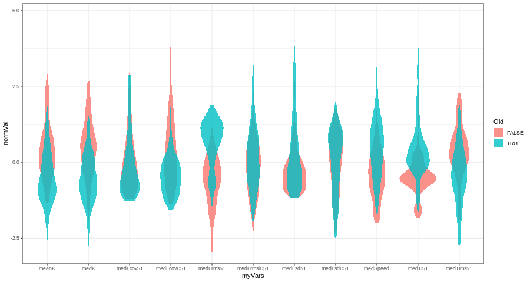

```python
%%R -w 900 -h 480 -u px
p
```

```python
%%R
# Installing 'tikzDevice' in the container add the following to the docker file
# Dockerfile
# RUN R -e "install.packages('tikzDevice',dependencies=TRUE, repos='http://cran.rstudio.com/')"

library('tikzDevice')
```

```python
%%R
# saving the tex file
tikz("overlapping_violin_plots_Rtikz.tex",standAlone = TRUE, width=8, height=4)
   print(p)
dev.off()
```

[output not shown]

[output cut: 94 more lines]

[output not shown]

```python
# current directory
!pwd
```

```
/home/jovyan/work/slides
```

```python
# Creating the pdf file
!pdflatex overlapping_violin_plots_Rtikz.tex

# You can save the output in a different folder
# !pdflatex -output-directory=images/ images/overlapping_violin_plots_Rtikz.tex
```

[output not shown]

[output cut: 93 more lines]

[output not shown]

```python
# https://stackoverflow.com/questions/19470099/view-pdf-image-in-an-ipython-notebook
# displaying the result, works in firefox
# it seems not to be working on binder and chrome
from IPython.display import IFrame
IFrame("./overlapping_violin_plots_Rtikz.pdf", width=1000, height=600)
```

[interactive chart not shown]

### Assignment (01)

Visualize the relationship between mean curvature `medK` and speed `medSpeed` per participant. Create a grouped bar chart (see next plot) showing speed and curvature average values per participant `iSubj`.

1. Create a new normalized variable `normVal2` in `longTable` using the formula `(value - value.min())/(value.max())-value.min())`
2. Create a new (subset) dataframe `dfKS` that contains the key, plus curvature and speed variables. Tip: [Subset dataframes](https://pandas.pydata.org/docs/getting_started/intro_tutorials/03_subset_data.html)
3. Estimate mean curvature and speed `normVal2` grouped by `['iSubj','myVars','Age']`. Tip: [Dataframe group by](https://pandas.pydata.org/pandas-docs/version/0.23.1/generated/pandas.core.groupby.DataFrameGroupBy.agg.html), covert the result to DataFrame and use `reset_index()`.
4. Select colors from https://colorbrewer2.org
5. Create the grouped bar chart. Tip: [Bar chart](https://plotly.com/python/bar-charts/) and look at previous slides to change the tick labels.

### Assignment (01)

Visualize the relationship between mean curvature `medK` and speed `medSpeed` per participant. Create a grouped bar chart (see next plot) showing speed and curvature average values per participant `iSubj`.

1. [Drop variables that you do not need](https://pandas.pydata.org/pandas-docs/stable/reference/api/pandas.DataFrame.drop.html) and convert to long format.
2. Create a new normalized variable `normVal2` in `longTable` using the formula `(value - value.min())/(value.max())-value.min())`
3. Estimate mean curvature and speed `normVal2` grouped by `['iSubj','myVars','Age']`. Tip: [Dataframe group by](https://pandas.pydata.org/pandas-docs/version/0.23.1/generated/pandas.core.groupby.DataFrameGroupBy.agg.html), covert the result to DataFrame and use `reset_index()`.
4. Select colors from https://colorbrewer2.org
5. Create the grouped bar chart. Tip: [Bar chart](https://plotly.com/python/bar-charts/) and look at previous slides to change the tick labels.

### Resulting plot.

[figure not shown]

Try to create a similar plot using `R`, `ggplot2` and `tikzDevice` (optional).